# Testing HMMs

# Setting Up

depmixS4 provides methods to fit hidden (latent) Markov models.

We observe an m-variate time series, meaning each at each time t we observe m characteristics of the process.

Underpinning this are n hidden states, and at the time of each observation the process is in one of the n states. We want to find which of these states we are in at any time t.

To estimate the parameters, depmixS4 uses Expectation-Minimizer (EM) method for unconstrained models (via Newton Raphson), and uses Direct Optimization for general linear (in)equality constraints.

Missing data is not a problem, as depmixS4 estimates the latent state probabilities for the missing time t with the data from times 1,…,t-1.

# Example - Speed

Here is an example using the dataset ‘speed’.

This data is from a psychological experiment where a person is observed answering questions over time.

This contains three time series with three variables: response time (rt), correct (corr), and payoff (Pacc) which is a covariate for the relative reward for the speed and accuracy of the response. The payoff at time t is known to the person before the question is given.

There are 439 observations, and the data also includes previous answer (prev).

The aim is of this test is to see if there are two distinct states (latent) for the person answering - a slow response state and a fast response state - rather than a continuous trade-off between speed and accuracy

```r
library("depmixS4")
data("speed")
str(speed)
```

```
'data.frame':   439 obs. of  4 variables:
 $ rt  : num  6.46 5.6 6.25 5.45 5.87 ...
 $ corr: Factor w/ 2 levels "inc","cor": 2 2 1 1 1 2 2 2 1 2 ...
 $ Pacc: num  0 0 0 0 0 ...
 $ prev: Factor w/ 2 levels "inc","cor": 1 2 2 1 1 1 2 2 2 1 ...
```

```r
#For initial values
set.seed(1)
#Initial model - with random transition probabilities to begin with
mod0 <- depmix(response = rt ~ 1, data = speed, nstates = 2, trstart = runif(4))
#Fit model and print results
#Controls EM algorithm for start values not to be generated
fm0 <- fit(mod0, emc=em.control(rand=FALSE))
```

```
iteration 0 logLik: -305.3309
iteration 5 logLik: -305.3303
iteration 10 logLik: -305.3294
iteration 15 logLik: -305.3276
iteration 20 logLik: -305.3241
iteration 25 logLik: -305.3168
iteration 30 logLik: -305.301
iteration 35 logLik: -305.2629
iteration 40 logLik: -305.1459
iteration 45 logLik: -304.4785
iteration 50 logLik: -276.7128
iteration 55 logLik: -89.82826
iteration 60 logLik: -88.73353
iteration 65 logLik: -88.7306
converged at iteration 68 with logLik: -88.73058
```

```r
#Print for info on convergence and AIC + BIC values
fm0
```

```
Convergence info: Log likelihood converged to within tol. (relative change)
'log Lik.' -88.73058 (df=7)
AIC:  191.4612
BIC:  220.0527
```

```r
summary(fm0)
```

```
Initial state probabilties model
pr1 pr2
  1   0

Transition matrix
        toS1  toS2
fromS1 0.916 0.084
fromS2 0.116 0.884

Response parameters
Resp 1 : gaussian
    Re1.(Intercept) Re1.sd
St1           6.385  0.244
St2           5.510  0.192
```

This display shows us: - Initial state proabilities - Transition probabilities - Response parameters - dependent on state - mean and sd

### Adding a Covariate

```r
set.seed(1)
mod1 <- depmix(rt ~ 1, data = speed, nstates = 2, family = gaussian(), transition = ~ scale(Pacc), instart = runif(2))
fm1 <- fit(mod1, verbose = FALSE, emc=em.control(rand=FALSE))
```

```
converged at iteration 42 with logLik: -44.19948
```

```r
summary(fm1)
```

```
Initial state probabilties model
pr1 pr2
  0   1

Transition model for state (component) 1
Model of type multinomial (mlogit), formula: ~scale(Pacc)
Coefficients:
            St1        St2
(Intercept)   0 -0.9518186
scale(Pacc)   0  1.3923616
Probalities at zero values of the covariates.
0.7214808 0.2785192

Transition model for state (component) 2
Model of type multinomial (mlogit), formula: ~scale(Pacc)
Coefficients:
            St1      St2
(Intercept)   0 2.471526
scale(Pacc)   0 3.581160
Probalities at zero values of the covariates.
0.07787861 0.9221214


Response parameters
Resp 1 : gaussian
    Re1.(Intercept) Re1.sd
St1           5.507  0.187
St2           6.386  0.242
```

This now shows us the transition models for each state, with state 1 as the base category for the logit model. This means that the output is showing the coefficients for: log(Pr(StX)/Pr(St1)) = (intercept) + (slope)*Pacc.

Set value of covariate: Transition probabilities are found by plugging in Pacc = Y and solving simeltaneously with Pr(St2)+Pr(St1)=1

### Multivariate data

Now using multivariate data - seeing how the state affects response time and how it affects accuracy

```r
set.seed(1)
mod2 <- depmix(list(rt ~ 1,corr ~ 1), data = speed, nstates = 2,
                 family = list(gaussian(), multinomial("identity")),
                 transition = ~ scale(Pacc), instart = runif(2))
fm2 <- fit(mod2, verbose = FALSE, emc=em.control(rand=FALSE))
```

```
converged at iteration 31 with logLik: -255.5337
```

Note: depmixS4 only has one multivariate response model which is for multivariate normal variables

### Contraints on Parameters

Using the function ‘fit’, and the ‘conpat’ argument, parameters can be given fixed or free values. Assigning fixed values with a 0 (in the vector) and other with other numbers (e.g. 1,2,3,…), and if two parameters are equal (but free) then they should be given the same number (e.g. 2 and 2). When only fixed values are required, can use the ‘fixed’ argument with zeros for fixed parameters and non-zero for others.

Number of parameters can be checked using:

```r
fm3 <- fm2
mod3 <- mod2
#Duplicating for next change
npar(fm3) #where fm is the object
```

```
[1] 18
```

Vector must be the same length as number of parameters. Parameters should be ordered in this way: Prior model parameters, parameter for transition models, response model parameters per state (and subsequently per response in the cast of multivariate time series).

Ordering can be visualed as below:

```r
setpars(mod3, value=1:npar(mod3))
```

```
Initial state probabilties model
pr1 pr2
  1   2

Transition model for state (component) 1
Model of type multinomial (mlogit), formula: ~scale(Pacc)
Coefficients:
            St1 St2
(Intercept)   3   4
scale(Pacc)   5   6
Probalities at zero values of the covariates.
0.0133898 0.7310586

Transition model for state (component) 2
Model of type multinomial (mlogit), formula: ~scale(Pacc)
Coefficients:
            St1 St2
(Intercept)   7   8
scale(Pacc)   9  10
Probalities at zero values of the covariates.
0.0002452428 0.7310586


Response parameters
Resp 1 : gaussian
Resp 2 : multinomial
    Re1.(Intercept) Re1.sd Re2.inc Re2.cor
St1              11     12      13      14
St2              15     16      17      18
```

```r
#mod3 <- setpars(mod3, getpars(mod, which = "fixed"))
#Has error?
```

```r
trst <- c(0.9, 0.1, 0, 0, 0.1, 0.9, 0, 0)
mod4 <- depmix(list(rt ~ 1,corr ~ 1), data = speed, transition = ~ Pacc, nstates = 2, family = list(gaussian(), multinomial("identity")), trstart = trst, instart = c(0.99, 0.01))
#Can be included to test
#respst <- c(0.1, 1.5, 0.3, 0.7, 0.2, 1.1, 0.4, 0.6)
#respstart = respst
```

We can specify the parameters for the model using the following: trstart: sets the parameters in the transition models respstart: sets parameters in response models instant: sets the parameters of the prior/initial state model

Note - this is not the same as saying that a parameter has a fixed value

### Generating a Model - with specified parameters

Now to generate the model with these specified parameters

```r
fm4 <- fit(mod4,verbose = FALSE, emc=em.control(rand=FALSE))
```

```
converged at iteration 23 with logLik: -255.5337
```

```r
summary(fm4)
```

```
Initial state probabilties model
pr1 pr2
  0   1

Transition model for state (component) 1
Model of type multinomial (mlogit), formula: ~Pacc
Coefficients:
            St1       St2
(Intercept)   0 -3.425752
Pacc          0  6.854772
Probalities at zero values of the covariates.
0.9684997 0.03150029

Transition model for state (component) 2
Model of type multinomial (mlogit), formula: ~Pacc
Coefficients:
            St1       St2
(Intercept)   0 -3.411245
Pacc          0 15.940160
Probalities at zero values of the covariates.
0.9680541 0.03194587


Response parameters
Resp 1 : gaussian
Resp 2 : multinomial
    Re1.(Intercept) Re1.sd Re2.inc Re2.cor
St1           5.517  0.197   0.475   0.525
St2           6.391  0.239   0.098   0.902
```

Now we can constrain parameters:

The pars commands: are fixing the Pacc value for transitioning to state 2 from both states, the initial state probabilities and saying that answering incorrect/correct in State 1 is by pure change (50/50).

fit optimizes parameters of a depmix model that is subject to (in)equality constraints

```r
pars <- c(unlist(getpars(fm4)))
pars[6] <- pars[10] <- 11
pars[1] <- 0
pars[2] <- 1
pars[13] <- pars[14] <- 0.5
fm5 <- setpars(mod4, pars)
conpat <- c(0, 0, rep(c(0, 1), 4), 1, 1, 0, 0, 1, 1, 1, 1)
conpat[6] <- conpat[10] <- 2
```

The equal command: states which of the values are subject to equality constraints in the model. Zeros mean that values are fixed at their starting values, ones mean that the values are free, and other number pairing (e.g. twos) mean that these parameters are free but must take the same value (equality)

```r
fm5 <- fit(fm4, equal = conpat)
```

```
longer object length is not a multiple of shorter object length
```

```
Iter: 1 fn: 255.5337     Pars:  -3.42575  6.85477 -3.41125 15.94016  5.51697  0.19739  6.39131  0.23858  0.09790  0.90210
solnp--> Solution not reliable....Problem Inverting Hessian.
```

```r
summary(fm5)
```

```
Initial state probabilties model
pr1 pr2
  0   1

Transition model for state (component) 1
Model of type multinomial (mlogit), formula: ~Pacc
Coefficients:
            St1       St2
(Intercept)   0 -3.425752
Pacc          0  6.854772
Probalities at zero values of the covariates.
0.9684997 0.03150029

Transition model for state (component) 2
Model of type multinomial (mlogit), formula: ~Pacc
Coefficients:
            St1       St2
(Intercept)   0 -3.411245
Pacc          0 15.940160
Probalities at zero values of the covariates.
0.9680541 0.03194587


Response parameters
Resp 1 : gaussian
Resp 2 : multinomial
    Re1.(Intercept) Re1.sd Re2.inc Re2.cor
St1           5.517  0.197   0.475   0.525
St2           6.391  0.239   0.098   0.902
```

### LR Test

Can use an LR test on contraints:

```r
llratio(fm4,fm5)
```

```
log Likelihood ratio (chi^2): 0 (df=3), p=1.
```

# Adding Covariates on the Prior Probabilities

## New Example: Balance Test

Balance test: 779 children aged 5-19 are shown a balance scale with 8 weights, which can be placed in various combination on either side, with various lengths along each side. There are two rules. Rule 1 - determining which side will tip towards based only on number of weights on that side Rule 2 - taking distance into account when deciding for tipping side, but in doing so ignore the number of weights on each side

Age is a covariate used to test whether as children get older, they are more likely to apply Rule 2. Prior probabilities are regressed on age.

### Within the Data

4 Trichotomous items: 1 = left, 2 = balanced, 3 = right 4 Dichotomous items: 0 = incorrect, 1 = correct

We have used ‘mix’ rather than ‘depmix’ because the observations are independent. Hence, there are no transitions.

## Fitting the Model

```r
data("balance")
set.seed(1)
mod_b <- mix(list(d1 ~ 1, d2 ~ 1, d3 ~ 1, d4 ~ 1), data = balance, nstates = 3, family = list(multinomial("identity"), multinomial("identity"), multinomial("identity"), multinomial("identity")), respstart = runif(24), prior = ~ age, initdata = balance)
fm_b <- fit(mod_b, verbose = FALSE, emc=em.control(rand=FALSE))
```

```
converged at iteration 77 with logLik: -917.5344
```

```r
summary(fm_b)
```

```
Mixture probabilities model
Model of type multinomial (mlogit), formula: ~age
Coefficients:
            St1       St2        St3
(Intercept)   0  6.395659  1.7547928
age           0 -0.676301 -0.2905205
Probalities at zero values of the covariates.
0.001650109 0.9888085 0.009541344

Response parameters
Resp 1 : multinomial
Resp 2 : multinomial
Resp 3 : multinomial
Resp 4 : multinomial
         Re1.1     Re1.2      Re2.1      Re2.2      Re3.1     Re3.2
St1 0.02659988 0.9734001 0.02273903 0.97726097 0.02842106 0.9715789
St2 1.00000000 0.0000000 0.97281825 0.02718175 1.00000000 0.0000000
St3 0.60039517 0.3996048 0.49009695 0.50990305 0.63586414 0.3641359
         Re4.1        Re4.2
St1 0.01906297 9.809370e-01
St2 0.99999255 7.445536e-06
St3 0.36858481 6.314152e-01
```

The three states are the rules that are being used to create an answer. Responses are: ReX.1 = incorrect, ReX.2 = correct.

State 1 appears to be correct over 97% of the time, which may represent ‘Rule 2’.

State 2 is almost always incorrect, which indicates that this may be children applying ‘Rule 1’.

State 3 is a state that is different to the other two and by observing the probabilities, appears to be a guessing state.

### Why are we using 3 states?

```r
mod_b2 <- mix(list(d1 ~ 1, d2 ~ 1, d3 ~ 1, d4 ~ 1), data = balance, nstates = 2, family = list(multinomial("identity"), multinomial("identity"), multinomial("identity"), multinomial("identity")), respstart = runif(16), prior = ~ age, initdata = balance)
fm_b2 <- fit(mod_b2, verbose = FALSE, emc=em.control(rand=FALSE))
```

```
converged at iteration 14 with logLik: -951.2918
```

```r
mod_b4 <- mix(list(d1 ~ 1, d2 ~ 1, d3 ~ 1, d4 ~ 1), data = balance, nstates = 4, family = list(multinomial("identity"), multinomial("identity"), multinomial("identity"), multinomial("identity")), respstart = runif(32), prior = ~ age, initdata = balance)
fm_b4 <- fit(mod_b4, verbose = FALSE, emc=em.control(rand=FALSE))
```

```
converged at iteration 461 with logLik: -914.6564
```

```r
BIC(fm_b)
```

```
[1] 1941.597
```

```r
BIC(fm_b2)
```

```
[1] 1969.164
```

```r
BIC(fm_b4)
```

```
[1] 1975.789
```

### Drawing a Conclusion

Prior probabilities describe the probability of being in a certain state, based on age. This is used to conclude whether children will change the ‘rules’ they follow as they get older.

##### Help Needed To Plot

summary(fm, which = “prior”)

# Key Takeaways

### What is depmixS4 for:

- Using HMMs to create a model for which we specify the amount of latent states
- Fitted model estimates the parameters for prior probabilities, transition probabilities and response probabilities - conditioning on the latent state
- Working with either dependent (depmix) or independent data (mix)
- Determining the ‘best’ number of latent states

### Requirements for models that can be accomodated

- Multiple response variables
- Covariates which affect the response variable(s)
- Constraints on parameters: equality and inequality
- These constraints can be fixed or free (matching)
- Family for regression estimation (e.g. gaussian, multinomial)

### How does our data need to look

- Needs to be a data.frame with clearly defined response variables and covariates
- Data can have missing observations, as these are filled in using internal estimation

### Other comments

- We need to conceptualize the latent states we aim to understand
- Have clearly defined questions to answer
- Defining useful response variables is critical to the success of this project
- Prior (perhaps qualitative) insight into tennis decision making will help optimize selection of response variables, covariates and constraints

### Back to our Speed example…

# Visualising and Projecting States

Let’s begin by plotting the variables rt, Pacc and corr against time

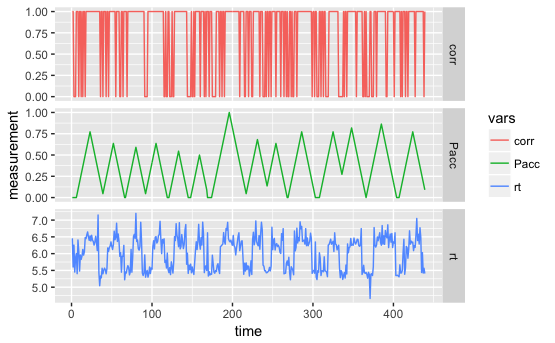

```r
library(ggplot2)
library(tidyr)
library(dplyr)
library(readr)
speed.df <- speed %>%
  dplyr::select(rt, corr, Pacc) %>%
  mutate(corr = sub("cor", "1", corr), corr = sub("inc", "0", corr)) %>%
  mutate(time = 1:nrow(speed))
speed.df$corr <- as.numeric(speed.df$corr)
speed.df.long <- speed.df %>%
  gather(key = vars, value = measurement, rt, corr, Pacc)
ggplot(speed.df.long, aes(x=time,y=measurement)) + geom_line(aes(color = vars)) + facet_grid(vars~., scale="free_y")
```

# Adding the predicted states

Let’s say initial probabilities are equal

We use fitted model 2 (fm2), which includes Pacc as a covariate and has no other contraints on the model

```r
pars <- getpars(fm2)
pars
```

```
            pr1             pr2 (Intercept).St1 (Intercept).St2
     0.00000000      1.00000000      0.00000000     -0.92650937
scale(Pacc).St1 scale(Pacc).St2 (Intercept).St1 (Intercept).St2
     0.00000000      1.59843492      0.00000000      2.40214266
scale(Pacc).St1 scale(Pacc).St2     (Intercept)              sd
     0.00000000      3.72236244      5.51695953      0.19737491
            inc             cor     (Intercept)              sd
     0.47472853      0.52527147      6.39130705      0.23858772
            inc             cor
     0.09790345      0.90209655
```

We are finding that we are always in state 2. This is problematic, and does not seem reasonable given the payoffs.

Initial suspicions can be noted from the baseline probabiltiies (Pacc=0) for each state. When Pacc=0, it means that there is no incentive to be accurate, and the player will choose speed, meaning they should be in state 1 (fast guessing state). However, the transition probability from state 2 to state 1 is 0.083, which is extremely unlikely given the proposed payoff effect. What we find is that this causes the player to remain in state 2 for the entire game (based on probabilities).

We are still interested in the likelihood of transitions. Let’s see how this visually fits the data.

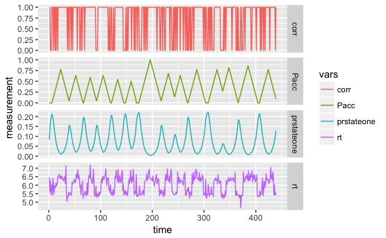

```r
speed.df2 <- mutate(speed.df, prstateone = pred.state[1:nrow(pacc.v),1])
speed.df2.long <- speed.df2 %>%
  gather(key = vars, value = measurement, rt, corr, Pacc, prstateone)
ggplot(speed.df2.long, aes(x=time,y=measurement)) + geom_line(aes(color = vars)) + facet_grid(vars~., scale="free_y")
```

### This is interesting and suspicious…

We see that the probability of being in state 1 clearly moves in the opposite direction to Pacc. At the same time, we are always significantly more likely to be in state 2.

There may be an issue with the code somewhere - I will be going through it again on monday - or this may be telling us more about the problem.

Inspection of a new dataset may give much more insight into the usefulness and power of this package.

# New Example:

Standard & Poor’s 500 - Stocks: Montly values for S&P500 index,

```r
data(sp500)
new_sp <- sp500 %>%
  mutate(ret = exp(logret))
msp <- depmix(logret~1,nstates=2,data=sp500)
set.seed(1)
fmsp <- fit(msp)
```

```
iteration 0 logLik: 1297.34
iteration 5 logLik: 1313.318
iteration 10 logLik: 1320.449
iteration 15 logLik: 1322.768
iteration 20 logLik: 1325.043
iteration 25 logLik: 1327.371
iteration 30 logLik: 1329.614
iteration 35 logLik: 1331.568
iteration 40 logLik: 1333.037
iteration 45 logLik: 1333.938
iteration 50 logLik: 1334.377
iteration 55 logLik: 1334.55
iteration 60 logLik: 1334.609
iteration 65 logLik: 1334.628
iteration 70 logLik: 1334.633
iteration 75 logLik: 1334.635
iteration 80 logLik: 1334.635
converged at iteration 85 with logLik: 1334.635
```